# NHANES Health Indicators — Hypothesis Testing

T.V.Q (James)

2026-04-24

## 1 Background

Hypothesis testing in statistics is a method for making decisions about a population based on sample data. Instead of collecting data from an entire population, a sample is taken from the population and the hypothesis test is conducted to find whether the evidence supports or contradicts an assumption about that population.

The assumptions about the population is called the hypotheses. There are 2 commonly stated hypotheses in the hypothesis testing, which are the **Null hypothesis** $H_0$, usually stating that there is no difference or no relationship, and the **Alternative hypothesis** $H_1$, usually stating that there are some differences or some relationships.

Hypothesis testing is central to biostatistics because it allows biostatisticians to make inference of the whole population based on just a small fraction of it. Leading to resources saving and fulfillment of ethical principles.

## 2 The p-value

### 2.1 What does a p-value actually measure

The p-value measures the probability of obtaining results at least as extreme as the observed results, assuming that the Null hypothesis $H_0$ is true. Therefore, if the p-value is small, we can conclude that the chance of obtaining the observed results is low under $H_0$.

When the p-value is smaller than a threshold or a significant level $\alpha$, usually 0.05, there is enough evidence to reject the Null hypothesis.

### 2.2 Why is p < 0.05 not the same as “important”

When the significant level is set at 0.05 and the obtained p-value < 0.05, we can reject the Null hypothesis of no difference or no relationship. When we compare two quantities (e.g. the means of 2 population or the means of 2 samples), if we reject the Null hypothesis, we can be confident that there is a difference between these two quantities.

However, the p-value is not associated with the magnitude of the difference. For example, when we compare the Average Systolic BP between 2 genders in NHANES dataset, the obtained p-value is smaller than $2 \times 10^{-16}$, thus indicating that there is a difference between the means of Average Systolic BP between 2 genders. The difference between two means is 4.11 mmHg with the Cohen’s size effect is 0.238, indicating only small effect. Further more, in clinical practice, the difference of just 4.11 mmHg is not considered as a clinically significant difference

Thus a result can be highly significant and clinically trivial at the same time.

### 2.3 What must always accompany a p-value?

The outputs commonly accompany with a p-value are effect size, confidence interval, and sample size. * **effect size**: as stated above, the effect size should be reported with the p-value for consideration in clinical practice. The difference may be statistically significant but not clinically significant.

- **sample size**: one of the key factors to evaluate the power of the test. Usually a large sample is associated with a high power test. When the p-value may not be small enough to reject the Null hypothesis, one can think of the reason that the sample size is not large enough to give the test enough power to detect the difference. However, in reverse, one might think that with thousands of observations, even a small difference would produce such a small p-value.
- **confidence interval**: a range of values, derived from sample data, that likely contains the true value of an unknown population parameter. It indicates the precision of an estimate, usually expressed with a percentage (e.g., 95% confident) that the interval captures the true value in repeated sampling.

## 3 Test 1 — Average Systolic BP by Gender (t-test)

- Null hypothesis $H_0$: there is no difference between the mean of the Average Systolic blood pressure across genders
- Alternative hypothesis $H_1$: there is a difference between the mean of the Average Systolic blood pressure across genders

### 3.1 Data preparation

```r
# Load the library
library(NHANES) ## For NHANES dataset
library(dplyr) ## For data manipulation
library(ggplot2) ## For graphs
library(moments) ## For skewness() function
library(patchwork) ## To combine multiple plots into a single layout
library(knitr) ## For kable() function
library(kableExtra) ## For styling kable table

# Filter the adult population from NHANES dataset
## remove all duplicate rows
nhanes_adult <- NHANES |>
  filter(Age >= 18) |>
  distinct()

# Remove rows with missing data
bp_data <- nhanes_adult |>
  filter(!is.na(BPSysAve), !is.na(Gender))
```

### 3.2 Density plots and Q-Q plots of Average Systolic BP by gender

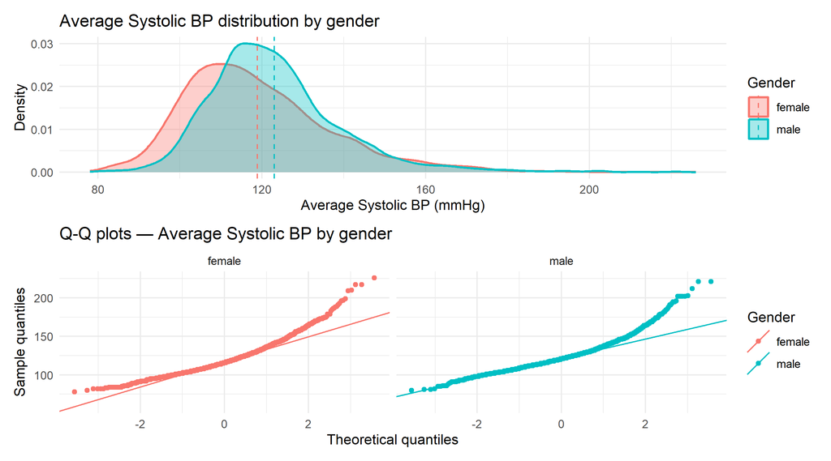

Figure 1. Density plots and Q-Q plots of Average Systolic BP by gender — NHANES adults (over 18 years old)

```r
# Create density curves of Average Systolic BP by gender
p1 <- ggplot(bp_data, aes(x = BPSysAve, fill = Gender, color = Gender)) +
  geom_density(alpha = 0.35, linewidth = 0.8) +
  geom_vline(
    data = bp_data |>
      group_by(Gender) |>
      summarise(m = mean(BPSysAve)), ### create a dataset of the means
    aes(xintercept = m, color = Gender), linetype = "dashed"
  ) +
  labs(title = "Average Systolic BP distribution by gender",
       x = "Average Systolic BP (mmHg)", y = "Density") +
  theme_minimal()

# Create Q-Q plots of Average Systolic BP by gender
p2 <- ggplot(bp_data, aes(sample = BPSysAve, color = Gender)) +
  ### "sample =" is a specialized aesthetic mapping for Q-Q plot
  stat_qq() + stat_qq_line() +
  facet_wrap(~Gender) +
  labs(title = "Q-Q plots — Average Systolic BP by gender",
       x = "Theoretical quantiles", y = "Sample quantiles") +
  theme_minimal()

# Create the combined plot
p1 / p2
```

### 3.3 Results of Welch’s t-test

```r
# Run the Welch’s t-test
t_result <- t.test(BPSysAve ~ Gender, data = bp_data, var.equal = FALSE)

# Calculate Cohen's size effect
## Calculate pooled SD
n1        <- sum(bp_data$Gender == "male")
n2        <- sum(bp_data$Gender == "female")
sd1       <- sd(bp_data$BPSysAve[bp_data$Gender == "male"])
sd2       <- sd(bp_data$BPSysAve[bp_data$Gender == "female"])
pooled_sd <- sqrt(((n1 - 1) * sd1^2 + (n2 - 1) * sd2^2) / (n1 + n2 - 2))

## Calculate Cohen's size effect
cohens_d <- abs(diff(t_result$estimate)) / pooled_sd

## Interpretation of Cohen's size effect
cohens_i <- ifelse(cohens_d < 0.2, "negligible effect",
  ifelse(cohens_d < 0.5, "small effect",
    ifelse(cohens_d < 0.8, "medium effect", "large effect")
  )
)

# Create the summary table
summary_t <- data.frame(
  statistic = round(t_result$statistic, 3),
  df        = round(t_result$parameter, 1),
  p_value   = format.pval(t_result$p.value, digits = 3),
  conf_low  = round(t_result$conf.int[1], 2),
  conf_high = round(t_result$conf.int[2], 2),
  cohen_d   = round(cohens_d, 3),
  cohen_d   = cohens_i
)

# Report the summary table
kable(summary_t,
  caption = "Table 1. Welch’s t-test
              of Average Systolic BP by gender — NHANES adults
              (over 18 years old)",
  col.names = c("Statistic", "DF", "p-value", "95% CI Lower", "95% CI Upper",
    "Cohen's d", "Interpretation"
  )
)
```

Table 1. Welch’s t-test of Average Systolic BP by gender — NHANES adults (over 18 years old)

|  | Statistic | DF | p-value | 95% CI Lower | 95% CI Upper | Cohen’s d | Interpretation |
| --- | --- | --- | --- | --- | --- | --- | --- |
| t | -8.81 | 5400.9 | <2e-16 | -5.03 | -3.2 | 0.238 | small effect |

As the obtained p-value is smaller than $2 \times 10^{-16}$, we can reject the Null hypothesis of no difference. Therefore the difference in Average Systolic BP between genders is statistically significant.

However, as the Cohen’s size effect is only 0.238, indicating only small effect, this difference is not cinically meaningful.

## 4 Test 2 — BMI by Gender (Wilcoxon)

- Null hypothesis $H_0$: BMI distribution is identical in males and females
- Alternative hypothesis $H_1$: BMI distributions differ between males and females

### 4.1 Data preparation

```r
# Remove rows with missing data
bmi_data <- nhanes_adult |>
  filter(!is.na(BMI), !is.na(Gender))

# Filter male data
bmi_data_male <- bmi_data |>
  filter(Gender == "male")

# Filter female data
bmi_data_female <- bmi_data |>
  filter(Gender == "female")
```

### 4.2 Histograms and Q-Q plots of BMI by gender

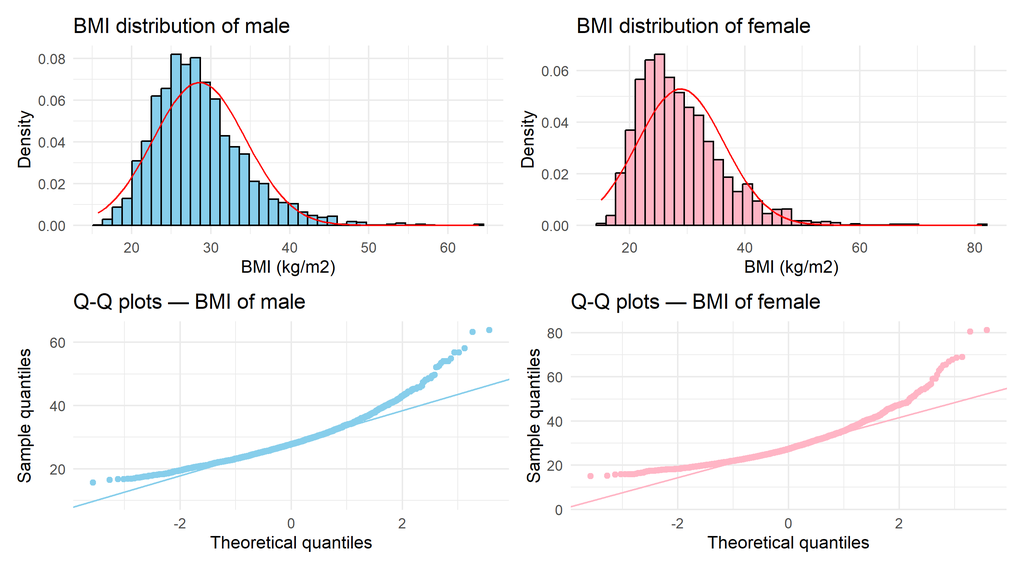

Figure 2. Histograms and Q-Q plots of BMI by gender — NHANES adults (over 18 years old)

```r
# Create histograms of BMI of male
p_hist_m <- ggplot(bmi_data_male, aes(x = BMI)) +
  geom_histogram(aes(y = after_stat(density)), bins = 40, fill = "skyblue",
                 color = "black") +
  stat_function(fun = dnorm,
    args = list(mean = mean(bmi_data_male$BMI),
                sd = sd(bmi_data_male$BMI)),
    colour = "red"
  ) +
  labs(title = "BMI distribution of male",
       x = "BMI (kg/m2)", y = "Density") +
  theme_minimal()

# Create histograms of BMI of female
p_hist_f <- ggplot(bmi_data_female, aes(x = BMI)) +
  geom_histogram(aes(y = after_stat(density)), bins = 40, fill = "pink1",
                 color = "black") +
  stat_function(fun = dnorm,
    args = list(mean = mean(bmi_data_female$BMI),
                sd = sd(bmi_data_female$BMI)),
    colour = "red"
  ) +
  labs(title = "BMI distribution of female",
       x = "BMI (kg/m2)", y = "Density") +
  theme_minimal()

# Create Q-Q plots of BMI of male
p_qq_m <- ggplot(bmi_data_male, aes(sample = BMI)) +
  stat_qq(color = "skyblue") + stat_qq_line(color = "skyblue") +
  labs(title = "Q-Q plots — BMI of male",
       x = "Theoretical quantiles", y = "Sample quantiles") +
  theme_minimal()

# Create Q-Q plots of BMI of female
p_qq_f <- ggplot(bmi_data_female, aes(sample = BMI)) +
  stat_qq(color = "pink1") + stat_qq_line(color = "pink1") +
  labs(title = "Q-Q plots — BMI of female",
       x = "Theoretical quantiles", y = "Sample quantiles") +
  theme_minimal()

# Create the combined plot
(p_hist_m | p_hist_f) / (p_qq_m | p_qq_f)
```

From the histograms and and Q-Q plots, we can see that the distributions of BMI by gender are not normal, which violates the assumption of normality when using t-test. Therefore, the nonparametric Wilcoxon rank-sum test is used

### 4.3 Results of Wilcoxon rank-sum test

```r
# Run the Wilcoxon rank-sum test
wilcox_result <- wilcox.test(BMI ~ Gender, data = bmi_data, conf.int = TRUE)

# Calculate medians and IQRs per group
bmi_median <- bmi_data |>
  group_by(Gender) |>
  summarise(
    n      = n(),
    median = median(BMI),
    iqr    = IQR(BMI)
  )

# Create a summary table
summary_w <- data.frame(
  statistic = wilcox_result$statistic,
  p_value   = format.pval(wilcox_result$p.value, digits = 3),
  conf_low  = round(wilcox_result$conf.int[1], 2),
  conf_high = round(wilcox_result$conf.int[2], 2),
  m_m       = bmi_median$median[2],
  m_f       = bmi_median$median[1],
  i_m       = bmi_median$iqr[2],
  i_f       = bmi_median$iqr[1]
)


# Report the summary table
kable(summary_w,
  caption = "Table 2. Wilcoxon rank-sum test
              of BMI by gender — NHANES adults
              over 18 years old)",
  col.names = c("W statistic", "p-value", "95% CI Lower", "95% CI Upper",
    "BMI Median in Male", "BMI Median in Female", "Male IQR", "Female IQR"
  )
)
```

Table 2. Wilcoxon rank-sum test of BMI by gender — NHANES adults over 18 years old)

|  | W statistic | p-value | 95% CI Lower | 95% CI Upper | BMI Median in Male | BMI Median in Female | Male IQR | Female IQR |
| --- | --- | --- | --- | --- | --- | --- | --- | --- |
| W | 3847986 | 0.0838 | -0.6 | 0.03 | 27.8 | 27.33 | 6.945 | 9.18 |

As the obtained p-value is 0.0838, we can not reject the Null hypothesis of no difference. Therefore there is not statistically significant difference in BMI between genders. The BMI medians of male and female are 27.8 and 27.33, respectively.

## 5 Test 3 — Diabetes and Smoking (Chi-squared)

- Null hypothesis $H_0$: There is no association between Diabetes status and Smoking prevalence
- Alternative hypothesis $H_1$: There is an association between Diabetes status and Smoking prevalence

### 5.1 Data preparation

```r
# Remove rows with missing data
diab_smoke <- nhanes_adult |>
  filter(!is.na(Diabetes), !is.na(SmokeNow))
```

### 5.2 Visualization of Smoking prevalence by diabetes status

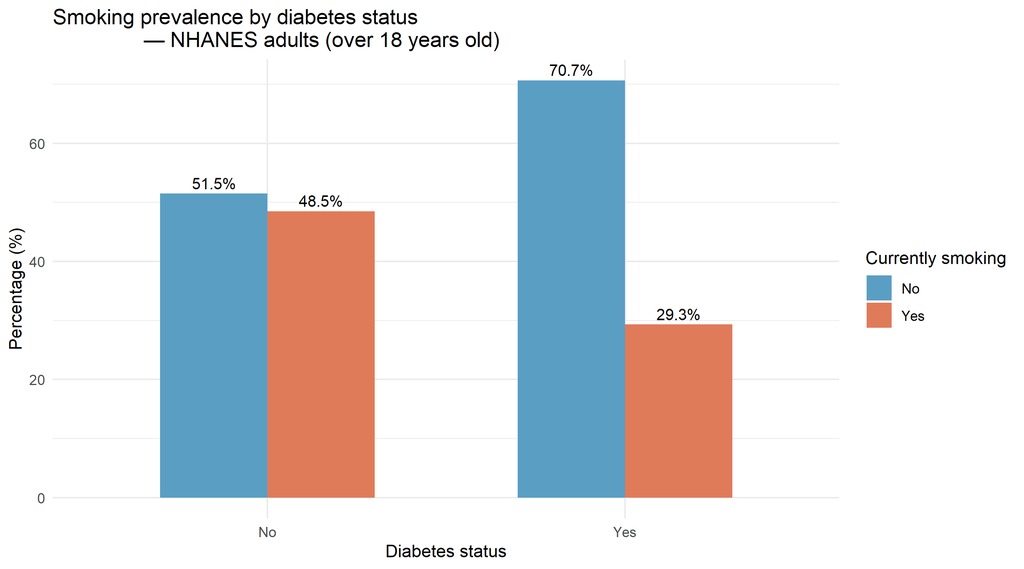

Figure 3. Smoking prevalence by diabetes status — NHANES adults (over 18 years old)

```r
diab_smoke |>
  count(Diabetes, SmokeNow) |>
  group_by(Diabetes) |>
  mutate(pct = n / sum(n) * 100) |>
  ggplot(aes(x = Diabetes, y = pct, fill = SmokeNow)) +
  geom_col(position = "dodge", width = 0.6) +
  geom_text(aes(label = paste0(round(pct, 1), "%")),
            position = position_dodge(width = 0.6),
            vjust = -0.4, size = 3.5) +
  labs(title = "Smoking prevalence by diabetes status
                — NHANES adults (over 18 years old)",
       x = "Diabetes status", y = "Percentage (%)",
       fill = "Currently smoking") +
  scale_fill_manual(values = c("Yes" = "#e07b5a", "No" = "#5a9ec4")) +
  theme_minimal()
```

### 5.3 Contingency table between Smoking prevalence by diabetes status

```r
# Create contingency table
cont_table <- table(Diabetes = diab_smoke$Diabetes,
  SmokeNow = diab_smoke$SmokeNow
) |>
  prop.table(margin = 1) * 100

# Report contingency table
kable(cont_table,
  digits = 1,
  caption = "Table 3. Contingency table of Smoking prevalence
              by Diabetes status — NHANES adults
              (over 18 years old)",
) |>
  add_header_above(c("Diabetes status" = 1, "Smoking prevalence" = 2))
```

Table 3. Contingency table of Smoking prevalence by Diabetes status — NHANES adults (over 18 years old)

| Diabetes status | Smoking prevalence No | Smoking prevalence Yes |
| --- | --- | --- |
| No | 51.5 | 48.5 |
| Yes | 70.7 | 29.3 |

### 5.4 Results of chi-squared test

```r
# Run the chi-squared test
chi_result <- chisq.test(cont_table)

# Calculate Cramér's V (effect size)
n         <- sum(cont_table)
cramers_v <- sqrt(chi_result$statistic /
                    (n * (min(nrow(cont_table), ncol(cont_table)) - 1)))

# Interpretation of Cohen's size effect
cramers_i <- ifelse(cramers_v < 0.1, "negligible association",
  ifelse(cramers_v < 0.3, "small association",
    ifelse(cramers_v < 0.5, "medium association", "large association")
  )
)

# Create a summary table
summary_chi <- data.frame(
  statistic = round(chi_result$statistic, 3),
  df        = chi_result$parameter,
  p_value   = format.pval(chi_result$p.value, digits = 3),
  cramers_v = round(cramers_v, 3),
  cramers_i = cramers_i
)

# Report the summary table
kable(summary_chi,
  caption = "Table 4. Chi-squared test of association between
              Smoking prevalence and Diabetes status — NHANES adults
              (over 18 years old)",
  col.names = c("Chi-sq", "DF", "p-value", "Cramér's V", "Interpretation"
  )
)
```

Table 4. Chi-squared test of association between Smoking prevalence and Diabetes status — NHANES adults (over 18 years old)

|  | Chi-sq | DF | p-value | Cramér’s V | Interpretation |
| --- | --- | --- | --- | --- | --- |
| X-squared | 6.963 | 1 | 0.00832 | 0.187 | small association |

### 5.5 Verify the expected cell counts

```r
print(round(chi_result$expected, 1))
```

```
##         SmokeNow
## Diabetes   No  Yes
##      No  61.1 38.9
##      Yes 61.1 38.9
```

As the obtained p-value is 0.00832, we can reject the Null hypothesis of no association. Therefore there is an association between Smoking prevalence and Diabetes status

However, as the Cramér’s V is only 0.187, there is only a small association between Smoking prevalence and Diabetes status

All the expected cell counts are larger than 5. Therefore, the chi-square test statistic is valid.

## 6 Reflection

- Get familiar with a lot of coding procedure such as pipeline, plotting figures, performing hypothesis test, etc.
- Get familiar with the hypothesis testing, from checking the assumptions to reporting outputs and interpreting results
- Get familiar with writing meaningful commit messages

## 7 Bonus: one-sample t-test

- Null hypothesis $H_0$: There is no different between the mean BMI in NHANES adults and WHO overweight threshold
- Alternative hypothesis $H_1$: There is different between the mean BMI in NHANES adults and WHO overweight threshold

```r
# Run the one-sample t-test
bmi_one <- t.test(nhanes_adult$BMI, mu = 25, na.rm = TRUE)

# Calculate Cohen's size effect

## Calculate SD
bmi_sd <- sd(nhanes_adult$BMI, na.rm = TRUE)

## Calculate Cohen's size effect
cohens_d_bmi <- abs(bmi_one$estimate - 25) / bmi_sd

## Interpretation of Cohen's size effect
cohens_i_bmi <- ifelse(cohens_d_bmi < 0.2, "negligible effect",
  ifelse(cohens_d_bmi < 0.5, "small effect",
    ifelse(cohens_d_bmi < 0.8, "medium effect", "large effect")
  )
)

summary_t_bmi <- data.frame(
  statistic = round(bmi_one$statistic, 3),
  df        = round(bmi_one$parameter, 1),
  p_value   = format.pval(bmi_one$p.value, digits = 3),
  conf_low  = round(bmi_one$conf.int[1], 2),
  conf_high = round(bmi_one$conf.int[2], 2),
  cohen_d   = round(cohens_d_bmi, 3),
  cohen_d   = cohens_i_bmi
)

# Report the summary table
kable(summary_t_bmi,
  caption = "Table 5. t-test of BMI and WHO overweight threshold
               — NHANES adults (over 18 years old)",
  col.names = c("Statistic", "DF", "p-value", "95% CI Lower", "95% CI Upper",
    "Cohen's d", "Interpretation"
  )
)
```

Table 5. t-test of BMI and WHO overweight threshold — NHANES adults (over 18 years old)

|  | Statistic | DF | p-value | 95% CI Lower | 95% CI Upper | Cohen’s d | Interpretation |
| --- | --- | --- | --- | --- | --- | --- | --- |
| t | 41.278 | 5624 | <2e-16 | 28.54 | 28.89 | 0.55 | medium effect |

As the obtained p-value is smaller than $2 \times 10^{-16}$, we can reject the Null hypothesis of no difference. Therefore the difference between the mean of BMI in NHANES adults and WHO overweight threshold is statistically significant.

The Cohen’s size effect is 0.55, indicating medium effect. Therefore, public health professionals should be aware that the adult population in NHANES can be considered as overweight